# GLM for Data With Non-Normal Distributions: Counts

When R builds diagnostics for a GLM, it uses something called the **standardized deviance residuals**. Again, these sound a lot more fancy than they really are. They are a specially transformed version of the raw residuals that make the transformed residuals normally distributed, if (and only if) the GLM family we’re using is appropriate.

What this means is, if the chosen family is a good choice for our data, then our diagnostics should behave like those from a model with normally distributed errors. The ‘normal Q–Q plot’ for the transformed residuals is checking whether the Poisson distribution is appropriate for the distribution of the residuals, and the scale–location plot is checking whether the mean–variance relationship is OK (it will only be patternless if the Poisson distribution is the right model).

```r
anova(sheep.poisson)
```

```
## Analysis of Deviance Table
##
## Model: poisson, link: log
##
## Response: fitness
##
## Terms added sequentially (first to last)
##
##
##           Df Deviance Resid. Df Resid. Dev  Pr(>Chi)
## NULL                         49     85.081
## body.size  1   37.041        48     48.040 1.157e-09 ***
## ---
## Signif. codes:  0 '***' 0.001 '**' 0.01 '*' 0.05 '.' 0.1 ' ' 1
```

Because the model is fit with maximum likelihood, we get deviance table. Deviance explained by body size is 37.0 units, unaccounted deviance is 48.0 and the total deviance (body size + unaccounted) is 85.0.

```r
summary(sheep.poisson)
```

```
##
## Call:
## glm(formula = fitness ~ body.size, family = poisson(link = log),
##     data = sheepfitness)
##
## Coefficients:
##             Estimate Std. Error z value Pr(>|z|)
## (Intercept) -2.42203    0.69432  -3.488 0.000486 ***
## body.size    0.54087    0.09316   5.806 6.41e-09 ***
## ---
## Signif. codes:  0 '***' 0.001 '**' 0.01 '*' 0.05 '.' 0.1 ' ' 1
##
## (Dispersion parameter for poisson family taken to be 1)
##
##     Null deviance: 85.081  on 49  degrees of freedom
## Residual deviance: 48.040  on 48  degrees of freedom
## AIC: 210.85
##
## Number of Fisher Scoring iterations: 4
```

What does the report tell us?

- coefficient tests: **Wald z-value** to tell us whether the estimate is significantly different from zero. Ratio of the estimate/SE for body size is 0.540/0.093 = 5.80.
- The model looks fine for over dispersion (48.0/48.0=1).
- AIC: to be used in comparing ‘fits’ of different nested models (more on this later).
- **We transform the coefficient to make a prediction**; remember that the GLM is predicting the natural logarithm of lifetime reproductive success. If we want to know how many lambs a 5 kg ewe is predicted to produce, we must account for what the link function did.

We can use our coefficients to interpret the slope and make predictions from our Poisson GLM.

**Slope ($\beta_1$)** The slope represents the change in the **log of expected counts** for a one-unit increase in $X$.

On the response scale, you **exponentiate the slope**:

$$e^{\beta_1}$$

This gives the **multiplicative effect** of a one-unit increase in $X$ on the expected count.

For example, if $\beta_1 = 0.25$:

$$e^{0.25} = 1.28$$

This means each 1-unit increase in $X$ increases the expected count by 28%.

*For our sheep,* if $\beta_1 = 0.54$:

$$e^{0.54} = 1.72$$

This means each 1-unit increase in 𝑋 increases the expected count by 72%.

What is the expected limetime fitness for a 5 kg sheep?

ANSWER=e^(-2.422+0.541*5), or 1.33 lambs.

```r
exp(-2.422+0.541*5)
```

```
## [1] 1.327105
```

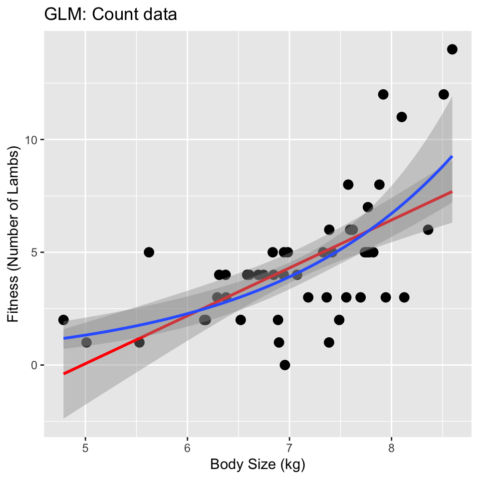

```r
ggplot(sheepfitness, aes(body.size, fitness)) +
  geom_point(size=3) +
  geom_smooth (method=lm, color="red") + #if you wanted to see the gaussian/identity fit
  stat_smooth(method = glm, method.args = list(family = poisson(link = "log"))) +
  labs(title="GLM: Count data") +
  xlab ("Body Size (kg)") +
  ylab ("Fitness (Number of Lambs)")
```

Is there a formal way to directly compare poisson and gaussian models? Some people (purists) say no, but I think there is a hack you can use to compare model fits. But remember, poisson was definitely the better model because it avoids prediction of values below zero and ‘bends’ to fit data.

```r
#first fit gaussian GLM
sheep.gaussian <- glm(fitness ~ body.size, data = sheepfitness, family = gaussian)
#compare poisson vs gaussian models.
compare_performance(sheep.poisson, sheep.gaussian, metrics = "common", verbose = FALSE)
```

```
## # Comparison of Model Performance Indices
##
## Name           | Model | AIC (weights) | BIC (weights) |  RMSE
## --------------------------------------------------------------
## sheep.poisson  |   glm | 210.8 (>.999) | 214.7 (>.999) | 2.096
## sheep.gaussian |   glm | 230.7 (<.001) | 236.4 (<.001) | 2.288
##
## Name           | Nagelkerke's R2 |    R2
## ----------------------------------------
## sheep.poisson  |           0.640 |
## sheep.gaussian |                 | 0.368
```

Clearly the Poisson model is better on both a prediction and ‘fit’ basis than the Gaussian model (Lower AICc score). We will talk about different criteria for comparing models in the chapter covering model selection.  
**Summary of GLM Counts**

- A GLM with a Poisson distribution is a good place to start when dealing with integer count data.
- The default log link function prevents the prediction of negative counts and with the Poisson distribution we assume that the variance is approximately equal to the mean.
- Overdispersion can be diagnosed and dealt with in a way similar to the analysis of binomial count data. However, just because data are integer counts does not mean the Poisson distribution will necessarily be a good model. The Poisson distribution generally applies well to data with many low values, including zeros.
- In the fertilizer example there was less variation than expected due to an absence of low values and we found *underdispersion*. When there are few low values and zeros, and the mean count rises, the Poisson distribution becomes similar to the normal distribution, as we observed for this example.
- The slope in a poisson model is the change in the **log of expected counts for a one-unit increase in 𝑋**. To make sense of the slope coefficient we must exponentiate it. (exponentiation is the inverse of log; our back transform) We can use exponentiation to make predictions based on the model coefficients in the usual GLM way.